# Homework 5

Hint: when you use the predicted probabilities from the knn model, try to take different threshold values and comment what is the optimal one.(0.5 might not work,)

```r
#Predicted KNN
confusionMatrix(knn_19, Test$Top10, positive = "Yes")
```

```
Confusion Matrix and Statistics

          Reference
Prediction   No  Yes
       No  1282  215
       Yes    9    8

               Accuracy : 0.852
                 95% CI : (0.8332, 0.8696)
    No Information Rate : 0.8527
    P-Value [Acc > NIR] : 0.5466

                  Kappa : 0.0468
 Mcnemar's Test P-Value : <2e-16

            Sensitivity : 0.035874
            Specificity : 0.993029
         Pos Pred Value : 0.470588
         Neg Pred Value : 0.856379
             Prevalence : 0.147292
         Detection Rate : 0.005284
   Detection Prevalence : 0.011229
      Balanced Accuracy : 0.514452

       'Positive' Class : Yes
```

```r
#The decision tree
predDT <- predict(model, newdata = Test , type = "class")
confusionMatrix(predDT, Test$Top10, positive = "Yes")
```

```
Confusion Matrix and Statistics

          Reference
Prediction   No  Yes
       No  1280  203
       Yes   11   20

               Accuracy : 0.8587
                 95% CI : (0.8401, 0.8758)
    No Information Rate : 0.8527
    P-Value [Acc > NIR] : 0.2706

                  Kappa : 0.1261
 Mcnemar's Test P-Value : <2e-16

            Sensitivity : 0.08969
            Specificity : 0.99148
         Pos Pred Value : 0.64516
         Neg Pred Value : 0.86312
             Prevalence : 0.14729
         Detection Rate : 0.01321
   Detection Prevalence : 0.02048
      Balanced Accuracy : 0.54058

       'Positive' Class : Yes
```

```r
#KNN with different threshold values
prob_knn<-attr(knn_19, "prob")
pred_knn1 = factor(ifelse(prob_knn>0.5,"Yes","No"))
pred_knn2 = factor(ifelse(prob_knn>0.75,"Yes","No"))
pred_knn3 = factor(ifelse(prob_knn>0.8,"Yes","No"))
confusionMatrix(pred_knn1, Test$Top10, positive = "Yes")
```

```
Levels are not in the same order for reference and data. Refactoring data to match.
```

```
Confusion Matrix and Statistics

          Reference
Prediction   No  Yes
       No     0    0
       Yes 1291  223

               Accuracy : 0.1473
                 95% CI : (0.1298, 0.1662)
    No Information Rate : 0.8527
    P-Value [Acc > NIR] : 1

                  Kappa : 0
 Mcnemar's Test P-Value : <2e-16

            Sensitivity : 1.0000
            Specificity : 0.0000
         Pos Pred Value : 0.1473
         Neg Pred Value :    NaN
             Prevalence : 0.1473
         Detection Rate : 0.1473
   Detection Prevalence : 1.0000
      Balanced Accuracy : 0.5000

       'Positive' Class : Yes
```

```r
confusionMatrix(pred_knn2, Test$Top10, positive = "Yes")
```

```
Confusion Matrix and Statistics

          Reference
Prediction   No  Yes
       No   229  100
       Yes 1062  123

               Accuracy : 0.2325
                 95% CI : (0.2114, 0.2546)
    No Information Rate : 0.8527
    P-Value [Acc > NIR] : 1

                  Kappa : -0.0973
 Mcnemar's Test P-Value : <2e-16

            Sensitivity : 0.55157
            Specificity : 0.17738
         Pos Pred Value : 0.10380
         Neg Pred Value : 0.69605
             Prevalence : 0.14729
         Detection Rate : 0.08124
   Detection Prevalence : 0.78269
      Balanced Accuracy : 0.36448

       'Positive' Class : Yes
```

```r
confusionMatrix(pred_knn3, Test$Top10, positive = "Yes")
```

```
Confusion Matrix and Statistics

          Reference
Prediction  No Yes
       No  369 139
       Yes 922  84

               Accuracy : 0.2992
                 95% CI : (0.2762, 0.323)
    No Information Rate : 0.8527
    P-Value [Acc > NIR] : 1

                  Kappa : -0.1376
 Mcnemar's Test P-Value : <2e-16

            Sensitivity : 0.37668
            Specificity : 0.28582
         Pos Pred Value : 0.08350
         Neg Pred Value : 0.72638
             Prevalence : 0.14729
         Detection Rate : 0.05548
   Detection Prevalence : 0.66446
      Balanced Accuracy : 0.33125

       'Positive' Class : Yes
```

(10 points) Build ROC curve and print AUC for both models. Comment on what is doing better.

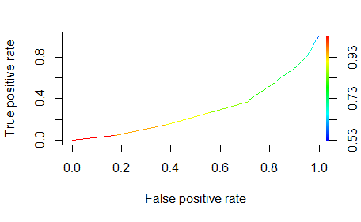

```r
#KNN
a <- prediction(prob_knn<-attr(knn_19, "prob"),Test$Top10)
perf_knn <- performance(a, "tpr","fpr")
plot(perf_knn, colorize = TRUE)
```

```r
performance(a,"auc")@y.values
```

```
[[1]]
[1] 0.2923934
```

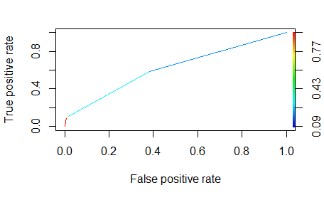

```r
#Decision Tree
pred1 <- predict(model, Test)
pred1 <- prediction(pred1[,2],Test$Top10)
perf = performance(pred1, "tpr", "fpr")
plot(perf, colorize = TRUE)
```

```r
performance(pred1, "auc")@y.values
```

```
[[1]]
[1] 0.6184815
```

The decision tree is doing better based on AUC value.

Naive bayes (15 points)Having the following contingency tables, build Naive Bayes Model, to predict the class label and respective probabilities of attrition for an employee who does not have a stock option and has worked overtime.

```r
p_no <- (751/987) * (378/987) * (987/1177)
p_yes <- (90/190) * (124/190) * (190/1177)
p_reg <- p_no / (p_no + p_yes)
p_reg
```

```
[1] 0.8304138
```

```
  worked overtime hasn't worked overtime  Sum
```

No 751 236 987 Yes 90 100 190 Sum 841 336 1177

```
no option option 1 option 2 option 3  Sum
```

No 378 430 122 57 987 Yes 124 45 10 11 190 Sum 502 475 132 68 1177

(5 points) Build another model using Naive Bayes on the training dataset. Commenton the tables of the model.

```r
model_NB<-naiveBayes(Top10~., data=Train, laplace=1)
```

(5 poits) Make confusion matrix, ROC Curve and calculate AUC. Does this model have more accurate results compared to knn and decision tree? Make your comments considering all the accuracy measures.

```r
pred_NB<-predict(model_NB, newdata=Test)
confusionMatrix(pred_NB, Test$Top10, positive="Yes")
```

```
Confusion Matrix and Statistics

          Reference
Prediction  No Yes
       No  967  93
       Yes 324 130

               Accuracy : 0.7246
                 95% CI : (0.7013, 0.747)
    No Information Rate : 0.8527
    P-Value [Acc > NIR] : 1

                  Kappa : 0.2324
 Mcnemar's Test P-Value : <2e-16

            Sensitivity : 0.58296
            Specificity : 0.74903
         Pos Pred Value : 0.28634
         Neg Pred Value : 0.91226
             Prevalence : 0.14729
         Detection Rate : 0.08587
   Detection Prevalence : 0.29987
      Balanced Accuracy : 0.66600

       'Positive' Class : Yes
```

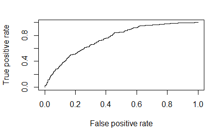

```r
pred_test_prob<-predict(model_NB, newdata=Test, type="raw")
p_test<-prediction(pred_test_prob[,2], Test$Top10)
perf<-performance(p_test, "tpr", "fpr")
plot(perf)
```

```r
performance(p_test, "auc")@y.values
```

```
[[1]]
[1] 0.7523177
```

In terms of accuracy the Decision tree has the highest value, while the Naive Bayes model has the highest auc value.